# MEDB 5501, Module02

2024-08-27

## Topics to be covered

- What you will learn
  - Counting
  - Mean and median
  - Percentiles
  - Standard deviation
  - Normality
  - TBA 1
  - Program template

## Count the occurrences of the letter “e”.

```
A quality control program is easiest
to implement from the top down.
Make sure that you understand the
the commitment of time and money
that is involved. Every workplace is
different, but think about allocating
10% of your time and 10% of the
time of all your employees to
quality control.
```

## A practical counting example

[figure not shown]

Image of a haemocytometer

## Measurement error

- Imprecision in a physical measurement
  - Example: GPS location
    - Can be off by up to 8 meters
    - Worse around large buildings
  - Other examples
    - Weight
    - Body temperature
    - Blood glucose

## Reducing measurement error

- Calibration
- Consistent environment
- Good equipment
- Quality control
- Training

## Errors of validity

- Mostly used for constructs
- Types of validity
  - Criterion
    - Concurrent
    - Predictive
  - Content/face
  - Many others
- Re-establishing validity

## Errors of reliability

- Synonym: repeatability(?)
- Not reproducibility
- Both physical measurements and constructs
- Types of reliability
  - Test-retest
  - Inter-rater
  - Inter-method

## Errors due to sampling

- To be covered later
- Easiest to quantify
- Less important in era of big data

## Break #0

- What you have learned
  - Counting
- What’s coming next
  - Mean and median

## Break #1

- What you have learned
  - Counting
- What’s coming next
  - Mean and median

## Calculation of the mean and median

- Mean
  - Add up all the values, divide by the sample size
- Median
  - Sort the data
    - Select the middle value if n is odd
    - go halfway between the two middle values if n is even

## Formal mathematical definitions

- Mean
  - $\bar{X}=\frac{1}{n}\Sigma X_i$
- Median
  - Sorted values $X_{[1]},X_{[2]},...,X_{[n]}$
    - $X_{[(n+1)/2]}$ if n is odd,
    - $(X_{[n/2]}+X_{[n/2+1]})/2$ if n is even

## Bacteria before and after A/C upgrade

```
Room Before  After
 121   11.8   10.1
 125    7.1    3.8
 163    8.2    7.2
 218   10.1   10.5
 233   10.8    8.3
 264   14     12
 324   14.6   12.1
 325   14     13.7
```

## Before remediation mean

```
11.8 + 7.1 + 8.2 + 10.1 + 10.8 + 14 + 14.6 + 14 = 90.6

90.6 / 8 = 11.325

Round to 11.3
```

## After remediation mean

```
10.1 + 3.8 + 7.2 + 10.5 + 8.3 + 12 + 12.1 + 13.7 = 77.7

77.7 / 8 = 9.7125

Round to 9.7
```

## Before remediation median (1/4)

```
121  11.8

125   7.1

163   8.2

218  10.1

233  10.8

264  14.0

324  14.6

325  14.0
```

## Before remediation median (2/4)

```
125   7.1

163   8.2

218  10.1

233  10.8

121  11.8

264  14.0

325  14.0

324  14.6
```

## Before remediation median (3/4)

```
125   7.1

163   8.2

218  10.1

233  10.8  10.8

121  11.8  11.8

264  14.0

325  14.0

324  14.6
```

## Before remediation median (4/4)

```
125   7.1

163   8.2

218  10.1

233  10.8  10.8
                  (10.8 + 11.8) / 2 = 11.3
121  11.8  11.8

264  14.0

325  14.0

324  14.6
```

## After remediation median (1/4)

```
121  10.1

125   3.8

163   7.2

218  10.5

233   8.3

264  12.0

324  12.1

325  13.7
```

## After remediation median (2/4)

```
125   3.8

163   7.2

233   8.3

121  10.1

218  10.5

264  12.0

324  12.1

325  13.7
```

## After remediation median (3/4)

```
125   3.8

163   7.2

233   8.3

121  10.1  10.1

218  10.5  10.5

264  12.0

324  12.1

325  13.7
```

## After remediation median (4/4)

```
125   3.8

163   7.2

233   8.3

121  10.1  10.1
                  (10.1 + 10.5) / 2 = 10.3
218  10.5  10.5

264  12.0

324  12.1

325  13.7
```

## Criticisms of the mean and median

- Are you combining apples and onions?
- Are you ignoring minorities?

[figure not shown]

Excerpt from Gould 1985 publication

## Choosing between the mean and median

- Often, either is fine
- When do you use the mean?
  - When totals are important
  - “In 2020, the average expenditure by the Italian National Health Service (Servizio Sanitario Nazionale, SSN) per patient affected by at least one chronic disease was approximately 696 euros.”
- When do you use the median
  - When outliers/skewness might distort your conclusions

[figure not shown]

Chen et al 2019

## Chen 2019, PMID: 31806195 (continued)

Background: The prices of newly approved cancer drugs have risen over the past decades. **A key policy question is whether the clinical gains offered by these drugs in treating specific cancer indications justify the price increases.**

## Chen 2019, PMID: 31806195 (continued)

Results: We found that between 1995 and 2012, price increases outstripped median survival gains, a finding consistent with previous literature. **Nevertheless, price per mean life-year gained increased at a considerably slower rate, suggesting that new drugs have been more effective in achieving longer-term survival.** Between 2013 and 2017, price increases reflected equally large gains in median and mean survival, resulting in a flat profile for benefit-adjusted launch prices in recent years.

## Break #2

- What you have learned
  - Mean and median
- What’s coming next
  - Percentiles

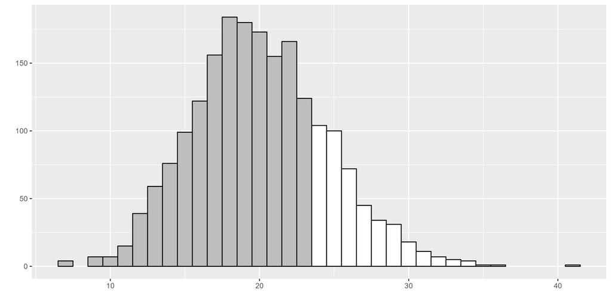

Illustration of the 75th percentile

## Computing percentiles

- Many formulas
  - Differences are not worth fighting over
- My preference (pth quantile)
  - Sort the data
  - Calculate p*(n+1)
  - Is it a whole number?
    - Yes: Select that value, otherwise
    - No: Go halfway between
    - Special cases: p(n+1) < 1 or > n

## Some examples of percentile calculations

- Example for n=39
  - For 5th percentile, p(n+1)=2 -> 2nd smallest value
  - For 4th percentile, p(n+1)=1.6 -> halfway between two smallest values
  - For 2nd percentile, p(n+1)=0.8 -> smallest value

## Some terminology

- Percentile: goes from 0% to 100%
- Quantile: goes from 0.0 to 1.0
  - 90th percentile = 0.9 quantile
- 25th, 50th, and 75th percentiles: quartiles
  - 25th percentile: $Q_1,\ X_{0.25}$ or lower quartile
  - Median/50th percentiles: $Q_2$ or $X_{0.5}$
  - 75th percentile: $Q_3,\ X_{0.75}$ or upper quartile

## Before remediation upper quartile (1/4)

```
121  11.8

125   7.1

163   8.2

218  10.1

233  10.8

264  14.0

324  14.6

325  14.0
```

## Before remediation upper quartile (2/4)

```
125   7.1

163   8.2

218  10.1

233  10.8

121  11.8

264  14.0

325  14.0

324  14.6
```

## Before remediation upper quartile (3/4)

```
125   7.1

163   8.2

218  10.1

233  10.8

121  11.8

264  14.0  14

325  14.0  14

324  14.6
```

## Before remediation upper quartile (4/4)

```
125   7.1

163   8.2

218  10.1

233  10.8

121  11.8

264  14.0  14
                  (14 + 14) / 2 = 14
325  14.0  14

324  14.6
```

## After remediation upper quartile (1/4)

```
121  10.1

125   3.8

163   7.2

218  10.5

233   8.3

264  12.0

324  12.1

325  13.7
```

## After remediation upper quartile (2/4)

```
125   3.8

163   7.2

233   8.3

121  10.1

218  10.5

264  12.0

324  12.1

325  13.7
```

## After remediation upper quartile (3/4)

```
125   3.8

163   7.2

233   8.3

121  10.1

218  10.5

264  12.0  12

324  12.1  12.1

325  13.7
```

## After remediation upper quartile (4/4)

```
125   3.8

163   7.2

233   8.3

121  10.1

218  10.5

264  12.0  12
                  (12 + 12.1) / 2 = 12.05
324  12.1  12.1

325  13.7
```

## When you should use percentiles

- Characterize variation
  - Middle 50% of the data
- Exposure issues
  - Not enough to control median exposure level
- Quantify extremes
  - What does “upper class” mean?
- Quality control
  - Almost all products must meet a minimum standard

## Break #3

- What you have learned
  - Percentiles
- What’s coming next
  - Standard deviation

## Standard deviation

$$S = \sqrt{\frac{1}{n-1}\Sigma(X_i-\bar{X})^2}$$

At least one alternative formula.

## Why is variation important

- Variation = Noise
  - Too much noise can hide signals
- Variation = Heterogeneity
  - Too little heterogeneity, hard to generalize
  - Too much heterogeneity, mixing apples and oranges
- Variation = Unpredictability
  - Too much unpredictability, hard to prepare for the future
- Variation = Risk
  - Too much risk can create a financial burden

## Should you try to minimize variation?

- Yes, for early studies
  - Easier to detect signals
  - Proof of concept trials
- No, for later studies
  - Easier to generalize results
  - Pragmatic trials

## Break #4

- What you have learned
  - Standard deviation
- What’s coming next
  - Normality

## The bell shaped curve

- Does your variation follow a bell shaped curve?
- Synonyms: normality, normal distribution
  - Values in the middle are most common
  - Frequencies taper off away from the center
  - Symmetry on either side
- A bell shaped curve = better characterization of variation

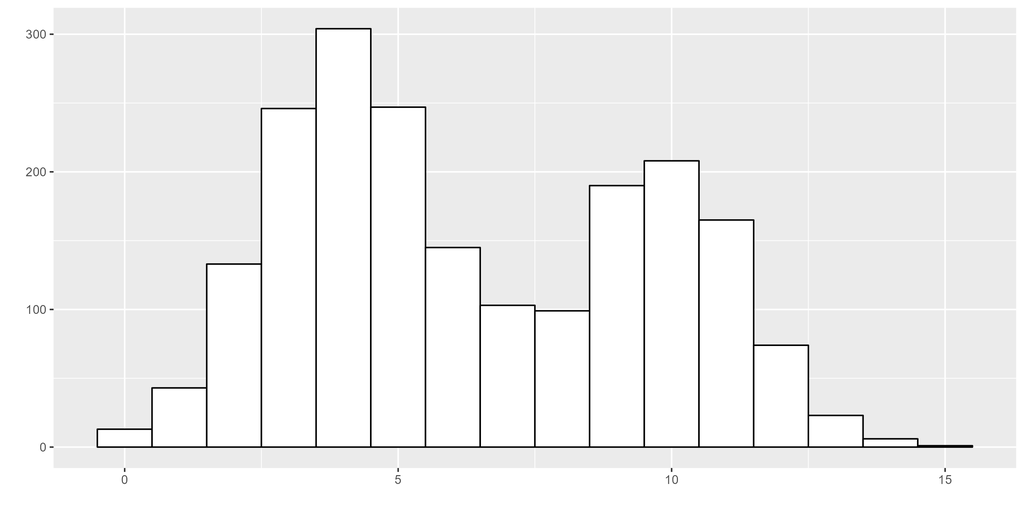

Bimodal histogram, not a bell shaped curve

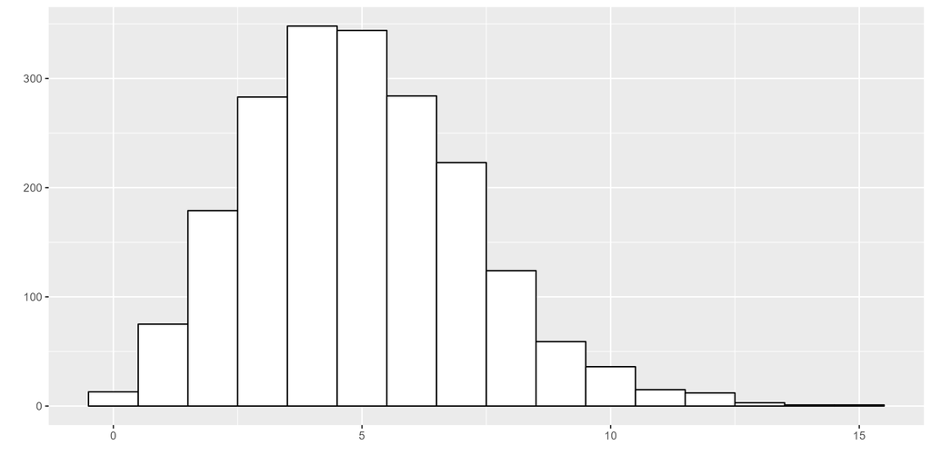

Skewed histogram, not a bell shaped curve

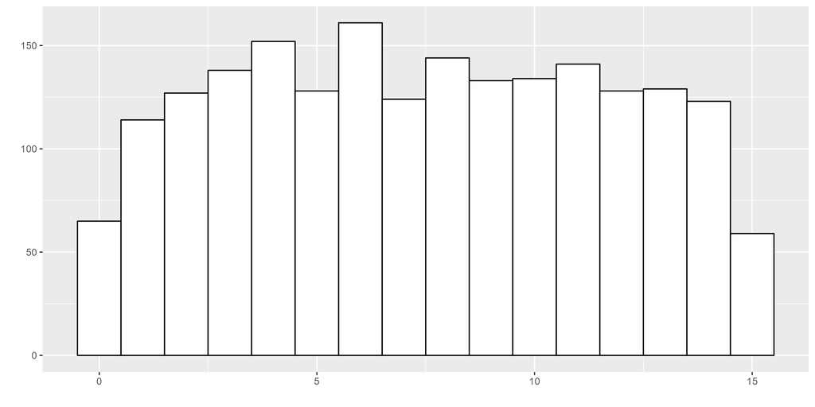

Uniform histogram, not a bell shaped curve

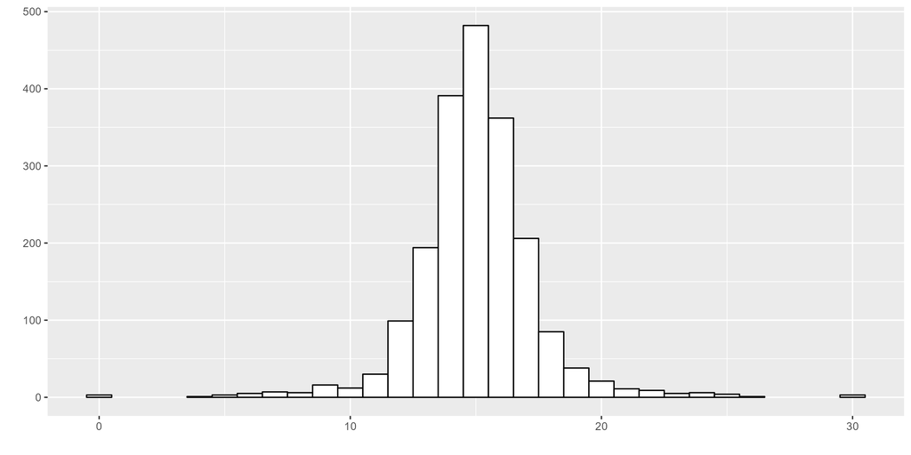

Heavy-tailed histogram, not a bell shaped curve

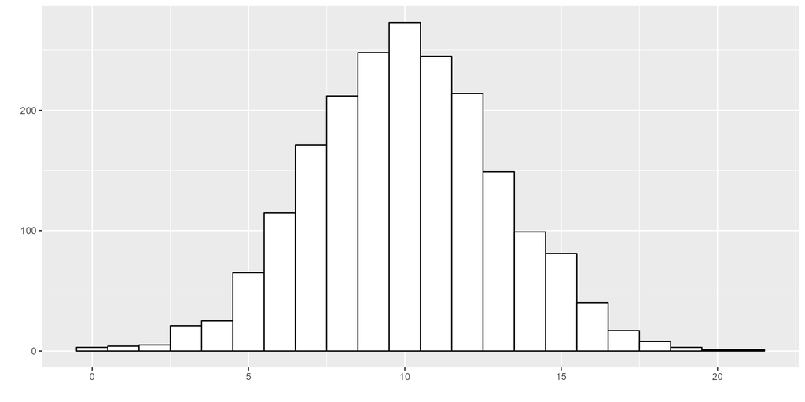

Bell-shaped histogram, finally!

## Break #5

- What you have learned
  - Normality
- What’s coming next
  - TBA 1

## Why concern yourself with the bell shaped curve?

- You can characterize individual observations
- You can characterize summary measures

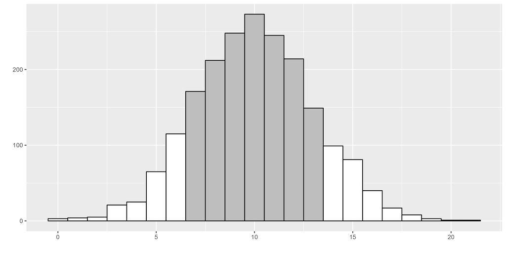

Percentage within one standard deviation

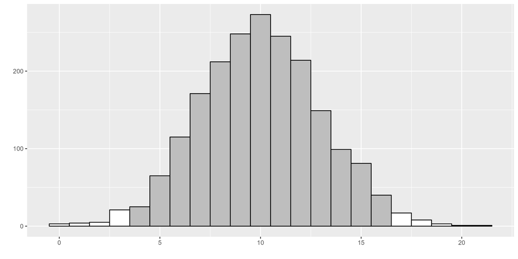

Percentage within two standard deviations

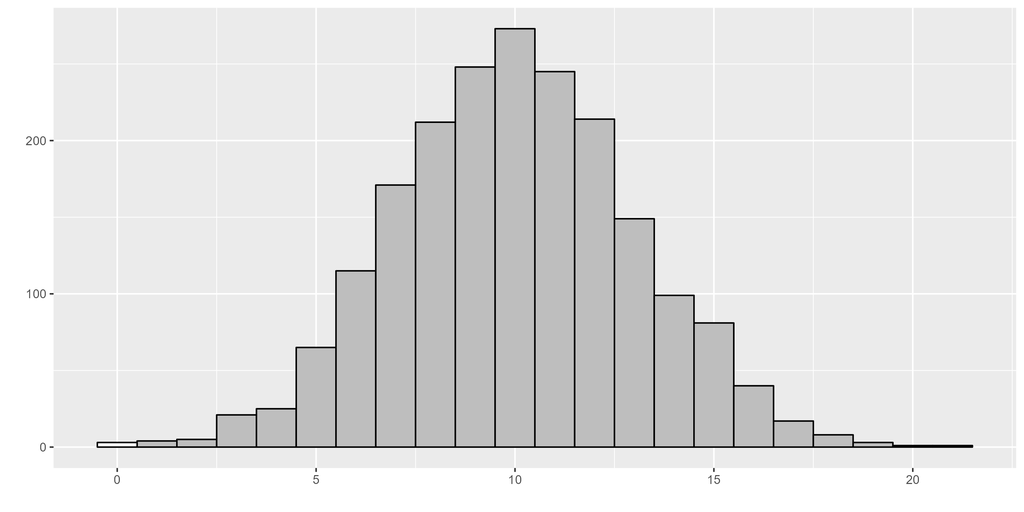

Percentage within three standard deviations

## Behavior of the mean versus an individual

- Central Limit Theorem
  - Sample mean is approximately normal
  - Even if individual observations are not
- Standard error: $S/\sqrt{n}$

## Break #6

- What you have learned
  - TBA 1
- What’s coming next
  - Program template

## Diagnosing distributional issues (1/2)

- For all data
  - $\bar{X} \gg X_{0.5}$
  - $\bar{X}$ and/or $X_{0.5}$ not midway between $Q_1$ and $Q_3$
  - $\bar{X}$ and/or $X_{0.5}$ not midway between min and max

## Diagnosing distributional issues (2/2)

- For non-negative data
  - $S > 0.5 \times \bar{X}$
- For data with an lower and/or upper bound
  - $Q_1$ = lower bound
  - $Q_3$ = upper bound
- Don’t overdiagnose, especially with small sample sizes!

[figure not shown]

Lin et al 2022, PMID: 36126916

[figure not shown]

Excerpt from Table 1 of Lin et al 2022: ages

[figure not shown]

Excerpt from Table 1 of Lin et al 2022: CCI

[figure not shown]

Excerpt from Table 1 of Lin et al 2022: PHQ-2

[figure not shown]

Tosato et al 2021, PMID: 34352201

## Tosato 2021, PMID: 34352201 (continued)

Symptom persistence weeks after laboratory-confirmed severe acute respiratory syndrome coronavirus 2 (SARS-CoV-2) clearance is a relatively common long-term complication of Coronavirus disease 2019 (COVID-19). Little is known about this phenomenon in older adults. The present study aimed at determining the prevalence of persistent symptoms among older COVID-19 survivors and identifying symptom patterns.

## Tosato 2021, PMID: 34352201 (continued)

The mean age was 73.1 ± 6.2 years (median 72, interquartile range 27), and 63 (38.4%) were women. The average time elapsed from hospital discharge was 76.8 ± 20.3 days (range 25-109 days).

## Ielapi 2021, PMID: 34968328

[figure not shown]

Ielapi et al 2021, PMID: 34968328

## Ielapi 2021, PMID: 34968328 (continued)

Background. Insomnia is one of the major health problems related with a decrease in quality of life (QOL) and also in poor functioning in night-shift nurses, that also may negatively affect patients’ care. The aim of this study is to evaluate the prevalence of insomnia in night shift nurses.

## Ielapi 2021, PMID: 34968328 (continued)

Excerpt from Table 1. Data reported as mean ± standard deviation or median [Q1-Q3]

```
Overall (n = 2′355)
Age, years  40.4 ± 10.3
Months of work 168 [72–300]
Night shifts per month, number  6.3 ± 1.4
Time to reach workplace, minutes    45 [45–65]
```

## Ielapi 2021, PMID: 34968328 (continued)

Excerpt from Table 1. Data reported as mean ± standard deviation or median [Q1-Q3]

```
Rest time, minutes  180 [4–240]
Rest in the afternoon, minutes  30 [0–120]
Number of coffees, mean 2.5 ± 1.5
Number of coffees during night shift, mean  1.4 ± 1.1
```

## Break #6

- What you have learned
  - Program template

## What’s coming next

## Normal probabilities in SPSS (P[Z < 2.5]=?)

[figure not shown]

Screenshot of SPSS dialog box

## Normal probabilities in SPSS (P[Z < 2.5]=0.9938)

[figure not shown]

Screenshot of SPSS data window

## Normal probabilities in SPSS (P[Z > 2.5]=?)

[figure not shown]

Screenshot of SPSS dialog box

## Normal probabilities in SPSS (P[Z > 2.5]=0.0062)

[figure not shown]

Screenshot of SPSS data window

## Normal probabilities in SPSS (P[-2.5 < Z < 2.5]=?)

[figure not shown]

Screenshot of SPSS dialog box

## Normal probabilities in SPSS (P[-2.5 < Z < 2.5]=0.9876)

[figure not shown]

Screenshot of SPSS data window

## Normal percentiles in SPSS (P[Z < ?]=0.75)

[figure not shown]

Screenshot of SPSS dialog box

## Normal percentiles in SPSS (P[Z < 0.67]=0.75)

[figure not shown]

Screenshot of SPSS data window

## Normal percentiles in SPSS (P[Z < ?]=0.25)

[figure not shown]

Screenshot of SPSS dialog box

## Normal percentiles in SPSS (P[Z < -0.67]=0.25)

[figure not shown]

Screenshot of SPSS data window

## Normal probability plot in SPSS (1/2)

[figure not shown]

Screenshot of SPSS dialog box

## Normal probability plot in SPSS (2/2)

[figure not shown]

Screenshot of SPSS data window

## Standardizing data in SPSS (1/2)

[figure not shown]

Screenshot of SPSS dialog box

## Normal probability plot in SPSS (2/2)

[figure not shown]

Screenshot of SPSS data window

## Summary

- What you have learned
  - Counting
  - Mean and median
  - Percentiles
  - Standard deviation
  - Normality
  - TBA 1
  - Program template